# ARIMAX/SARIMAX for Consumer Staples Sector Fund and macroeconomic factors

Endogenous variable: Consumer Staples Sector Fund Exogenous variables: Macroeconomic indicators such as GDP, inflation rate, unemployment rate and interest rates

Before proceeding with model selection, it can be useful to examine the feature variables and select the appropriate ones. This can be done by creating cross-correlation function plots, which can serve as a verification of the correlation heatmap for the variables.

##### CCF Plot for Consumer Staples Sector Fund and Exogenous Variables

**GDP**

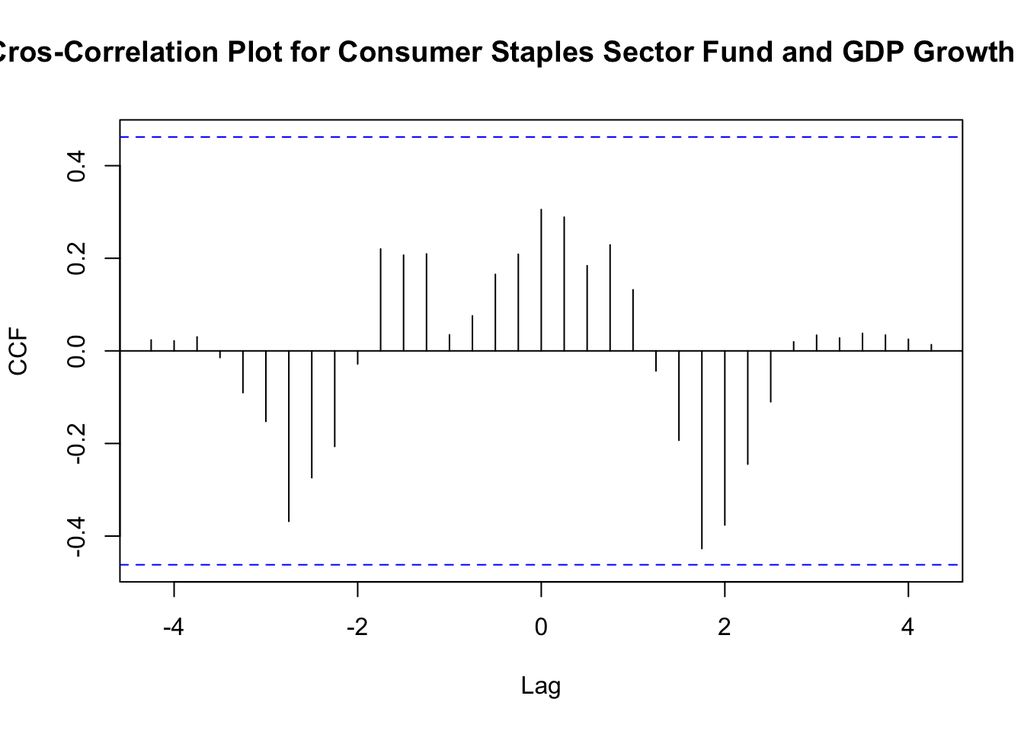

```r
par(mfrow=c(1,1))
ccf_result <- ccf(normalized_sector_factor_data[, c("XLP.Adjusted")], normalized_sector_factor_data[, c("gdp")],
    lag.max = 300,
    main = "Cros-Correlation Plot for Consumer Staples Sector Fund and GDP Growth Rate ",
    ylab = "CCF")
```

```r
cat("The sum of cross correlation function is", sum(abs(ccf_result$acf)))
```

```
The sum of cross correlation function is 5.056662
```

**Interest Rate**

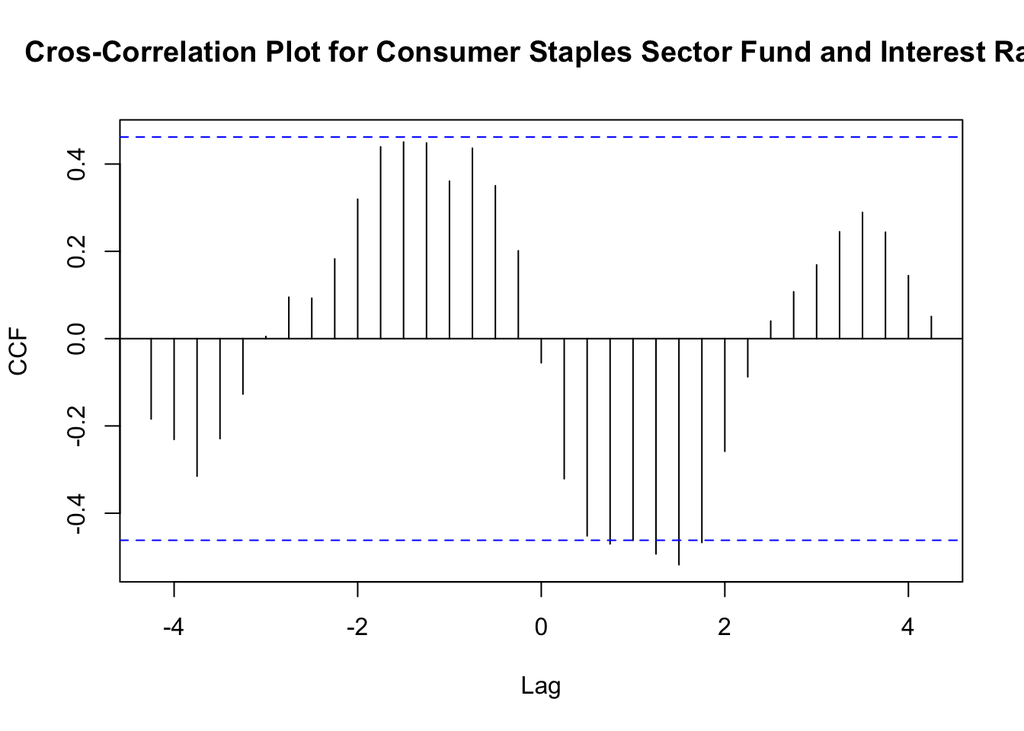

```r
par(mfrow=c(1,1))
ccf_result <- ccf(normalized_sector_factor_data[, c("XLP.Adjusted")], normalized_sector_factor_data[, c("interest")],
    lag.max = 300,
    main = "Cros-Correlation Plot for Consumer Staples Sector Fund and Interest Rate",
    ylab = "CCF")
```

```r
cat("The sum of cross correlation function is", sum(abs(ccf_result$acf)))
```

```
The sum of cross correlation function is 9.343761
```

**Inflation Rate**

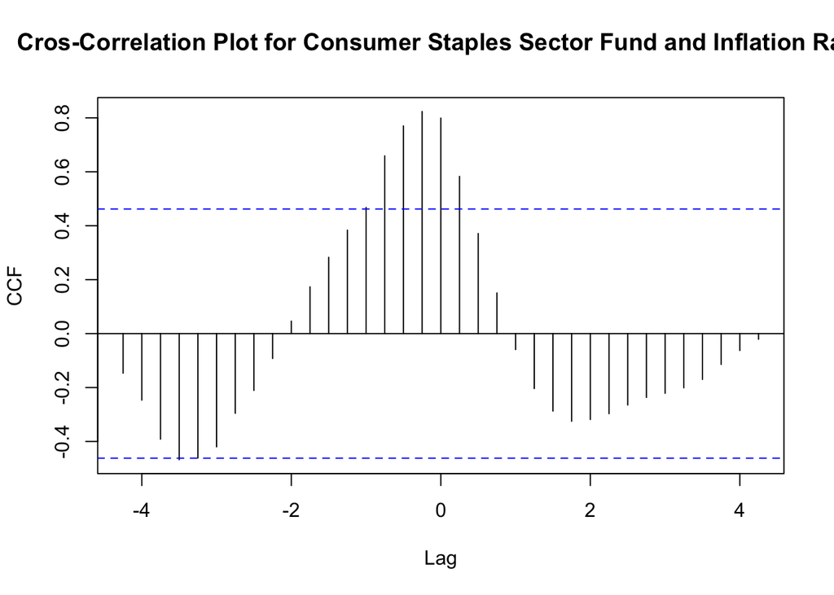

```r
par(mfrow=c(1,1))
ccf_result <- ccf(normalized_sector_factor_data[, c("XLP.Adjusted")], normalized_sector_factor_data[, c("inflation")],
    lag.max = 300,
    main = "Cros-Correlation Plot for Consumer Staples Sector Fund and Inflation Rate",
    ylab = "CCF")
```

```r
cat("The sum of cross correlation function is", sum(abs(ccf_result$acf)))
```

```
The sum of cross correlation function is 11.02386
```

**Unemployment Rate**

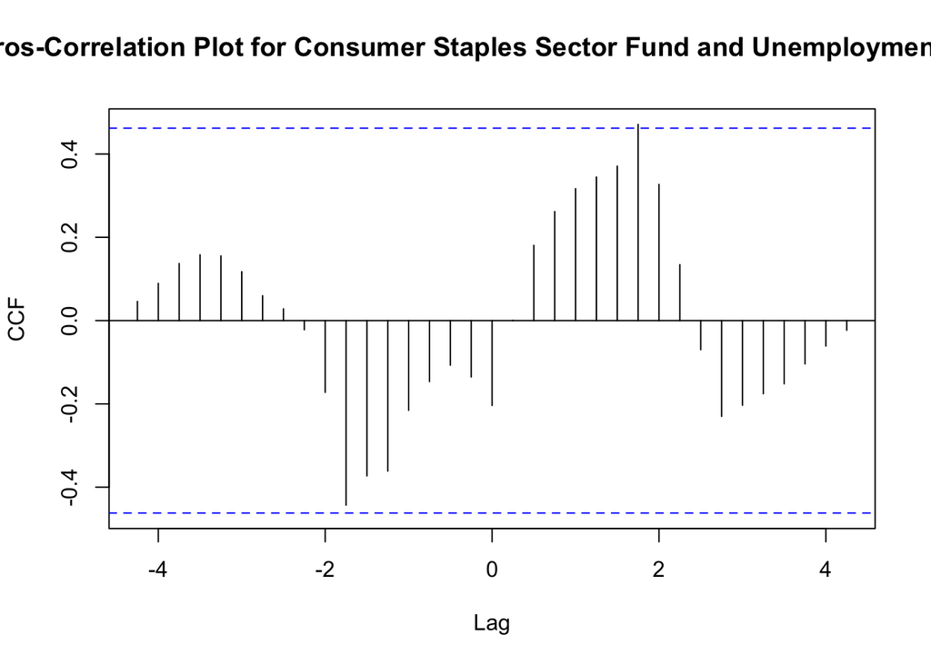

```r
par(mfrow=c(1,1))
ccf_result <- ccf(normalized_sector_factor_data[, c("XLP.Adjusted")], normalized_sector_factor_data[, c("unemployment")],
    lag.max = 300,
    main = "Cros-Correlation Plot for Consumer Staples Sector Fund and Unemployment Rate",
    ylab = "CCF")
```

```r
cat("The sum of cross correlation function is", sum(abs(ccf_result$acf)))
```

```
The sum of cross correlation function is 6.397481
```

The cross-correlation feature plots reaffirm the findings from the heatmap analysis, indicating that inflation rate exhibit stronger correlations with the index compared to GDP, interest rate and unemployment rate. The cross-correlation plots for GDP, unemployment and interest rates show weaker and more scattered patterns, with strikes between the blue lines indicating lower correlation coefficients. This suggests that inflation rate are more suitable feature variables for the ARIMAX model when predicting Consumer Staples Sector Fund movements.

Final Exogenous variables: Macroeconomic indicators: Inflation rate